# GSC-1790 Filtering - MirMaster Raw Data

Nikita Telkar

October 8, 2020

## ** Introduction **

1_3_filtering with only miRMaster data.

## **1.0 Loadings**

### **1.1 Loading Packages and Options**

```r
library(tidyverse)
library(dplyr)
library(plyr)
library(here)
library(readxl)
library(rmarkdown)
library(knitr)
library(stringr)
library(DT)
library(kableExtra)
library(formatR)
library(factoextra)
library(forcats)
library(janitor)
library(scales)
library(Rsamtools)
library(Rsubread)
library(pheatmap)
library(RColorBrewer)
library(ggsci)
library(biomaRt)
library(extrafont)
library(factoextra)
#library(NetBID2)
library(DESeq2)
library(edgeR)
library(showtext)
library(egg)
library(reshape2)
loadfonts(device = "win")
```

```r
#knitr::opts_chunk$set(tidy.opts=list(width.cutoff=50),tidy=TRUE)

font_add_google("Montserrat", "Mont")
showtext_auto()

my_theme <- theme_minimal() +
    theme(plot.title = element_text(family = "Mont", size = 14),
          plot.subtitle = element_text(family = "Mont", size = 12),
          legend.text = element_text(family = "Mont", size = 10),
          axis.title = element_text(family = "Mont", size = 14))

my_theme_2 <- theme (plot.title = element_text(family = "Mont", size = 14),
          plot.subtitle = element_text(family = "Mont", size = 12),
          legend.text = element_text(family = "Mont", size = 10),
          axis.title = element_text(family = "Mont", size = 14),
          strip.text.x = element_text("Mont", size = 10))

knitr::opts_chunk$set(fig.showtext = TRUE, fig_retina = 1) #needed to render show_text
knitr::opts_chunk$set(warning = FALSE, error = FALSE, message = FALSE)
```

```r
col_samp <- c("#801361", "#e44c4a", "#ffb708")

col_tirations <-  c("#87CEFA", "#87CEEB", "#00BFFF", "#1E90FF", "#4169E1", "#0000FF", "#00008B", "#0e0e3f")

col_filters <- c("#3c8012", "#7a9600", "#baa900", "#ffb708")

col_compare <- c("#ed9ca0", "#9cbd8c")
```

### **1.2 Loading Data**

Loading:

1. `eDat` - Count matrix: quantification_raw (rpm_normalised has decimal counts and is not recommended to be used for DE analysis)
2. `pDat` - Phenotype file
3. `mDat` - Metadata file
4. `eDat_s1` - Count Matrix of sample *PL-290* having sequences with 0 counts across all 8 samples removed
5. `eDat_s2` - Count Matrix of sample *TCR-2-18* having sequences with 0 counts across all 8 samples removed
6. `eDat_con` - Count Matrix of sample *FG0232A* having sequences with 0 counts across all 8 samples removed

```r
eDat <- read_excel(here::here("data", "external", "overview_run_sn1zmgd0_cs_test_all_500-0ng_test_1", "quantification_raw.xlsx"))
pDat <- readRDS(file = here::here('data', 'processed', "pDat_GSC_1790.rds"))
mDat <- readRDS(file = here::here('data', 'processed', "mDat_GSC_1790.rds"))


#cleaning up eDat
samples <- as.data.frame(colnames(eDat))
samples <- as.data.frame(samples[3:26,])
colnames (samples) [1] <- "samps"
samples$samps <- str_sub(samples$samps, 1, 6)

colnames(eDat)[3:26] <- samples$samps

eDat <- eDat %>%
  unite(miRNA, c("precursor", "miRNA")) %>%
  column_to_rownames(var = "miRNA")

eDat <- eDat %>%  #removing seqs which have 0 counts across all samples
  rownames_to_column(var = "miRNA") %>%
  mutate(Sum = rowSums(.[2:13])) %>%
  filter(Sum >= 1) %>%
  column_to_rownames(var = "miRNA") %>%
  dplyr::select(-Sum)

nrow(eDat) #1950
```

```
## [1] 1950
```

```r
#adding alt samp names to pDat

pDat <- pDat %>%
  mutate(Lab_name =
           case_when(
             sample == "PL-290v" ~ "Rob Lab T1",
             sample == "TCR-2-18_v_SNAP" ~ "Rob Lab T3",
             sample == "FG032A" ~ "GSC Control"
           )
         )


#Separating by sample

eDat_s1 <- eDat[c(1:8)]
eDat_s1 <- eDat_s1 %>%  #removing seqs which have 0 counts across all samples
  rownames_to_column(var = "miRNA") %>%
  mutate(Sum = rowSums(eDat_s1)) %>%
  filter(Sum >= 1) %>%
  column_to_rownames(var = "miRNA") %>%
  dplyr::select(-Sum)
nrow(eDat_s1) #1765
```

```
## [1] 1765
```

```r
eDat_s2 <- eDat[c(9:16)]
eDat_s2 <- eDat_s2 %>%  #removing seqs which have 0 counts across all samples
  rownames_to_column(var = "miRNA") %>%
  mutate(Sum = rowSums(eDat_s2)) %>%
  filter(Sum >= 1) %>%
  column_to_rownames(var = "miRNA") %>%
  dplyr::select(-Sum)
nrow(eDat_s2) #1720
```

```
## [1] 1720
```

```r
eDat_con <- eDat[c(17:24)]
eDat_con <- eDat_con %>%  #removing seqs which have 0 counts across all samples
  rownames_to_column(var = "miRNA") %>%
  mutate(Sum = rowSums(eDat_con)) %>%
  filter(Sum >= 1) %>%
  column_to_rownames(var = "miRNA") %>%
  dplyr::select(-Sum)
nrow(eDat_con) #1728
```

```
## [1] 1728
```

## **2.0 Filtering by Sample Counts**

Now, I’m going to take out the 0ng and 500ng samples (6 in total), since the previous 1_2_sample_correlations(path: "Z:_sorted\1_preprocessing\1_2_sample_correlations.html")

I’m going to be applying **5** filterieng criteria:

1. At least 1 count in 1 sample
2. At least 1 count in all samples
3. At least 2 counts across samples
4. At least 3 counts across samples
5. At least 4 counts across samples

```r
eDat_fil <- eDat [-c(1,8,9,16,17,24)] #removing 0 and 500ng samples

eDat2 <- eDat_fil %>% #removing sequences with less than 1 read count across all samples
  rownames_to_column(var = "miRNA") %>%
  mutate(Sum = rowSums(.[2:19])) %>%
  filter(Sum >= 1) %>%
  column_to_rownames(var = "miRNA") %>%
  dplyr::select(-Sum)

nrow(eDat2) #1911
```

```
## [1] 1911
```

```r
eDat3 <- eDat_fil %>% #keeping sequences with counts of atleast 1 in all of the samples
  rownames_to_column(var = "miRNA") %>%
  filter_all(all_vars(. >= 1))  %>%
  column_to_rownames(var = "miRNA")

nrow(eDat3) #445 --> too stringent
```

```
## [1] 445
```

```r
eDat4 <- eDat_fil %>% #removing sequences with less than 2 read count across all samples
  rownames_to_column(var = "miRNA") %>%
  mutate(Sum = rowSums(.[2:19])) %>%
  filter(Sum >= 2) %>%
  column_to_rownames(var = "miRNA") %>%
  dplyr::select(-Sum)

nrow(eDat4) #1775
```

```
## [1] 1775
```

```r
eDat5 <- eDat_fil %>% #removing sequences with less than 3 read count across all samples
  rownames_to_column(var = "miRNA") %>%
  mutate(Sum = rowSums(.[2:19])) %>%
  filter(Sum >= 3) %>%
  column_to_rownames(var = "miRNA") %>%
  dplyr::select(-Sum)

nrow(eDat5) #1671
```

```
## [1] 1671
```

```r
eDat6 <- eDat_fil %>% #removing sequences with less than 4 read count across all samples
  rownames_to_column(var = "miRNA") %>%
  mutate(Sum = rowSums(.[2:19])) %>%
  filter(Sum >= 4) %>%
  dplyr::arrange(Sum) %>%
  column_to_rownames(var = "miRNA") %>%
  dplyr::select(-Sum)

nrow(eDat6) #1585
```

```
## [1] 1585
```

I’ll now do some exploratory filtering on the 3 (PL290, TCR-2-18, FG032A) samples separately.

### **2.1 Filtering for PL290**

**PL290**

```r
s1_fil1 <- eDat2 [c(1:6)]

s1_fil1 <- s1_fil1 %>% #removing sequences with less than 1 read count across all samples
  rownames_to_column(var = "miRNA") %>%
  mutate(Sum = rowSums(.[2:7])) %>%
  filter(Sum >= 1) %>%
  column_to_rownames(var = "miRNA") %>%
  dplyr::select(-Sum)

nrow(s1_fil1) #1622
```

```
## [1] 1622
```

```r
s1_fil2 <- s1_fil1 %>% #keeping sequences with counts of atleast 1 in all of the samples
  rownames_to_column(var = "miRNA") %>%
  filter_all(all_vars(. >= 1))  %>%
  column_to_rownames(var = "miRNA")

nrow(s1_fil2) #576
```

```
## [1] 576
```

```r
s1_fil3 <- s1_fil1 %>% #keeping sequences with counts of atleast 2 in all of the samples
  rownames_to_column(var = "miRNA") %>%
  filter_all(all_vars(. >= 2))  %>%
  column_to_rownames(var = "miRNA")

nrow(s1_fil3) #495
```

```
## [1] 495
```

```r
s1_fil4 <- s1_fil1 %>% #keeping sequences with counts of atleast 3 in all of the samples
  rownames_to_column(var = "miRNA") %>%
  filter_all(all_vars(. >= 3))  %>%
  column_to_rownames(var = "miRNA")

nrow(s1_fil4) #450
```

```
## [1] 450
```

### **2.2 Filtering for TCR-5-18**

**TCR-2-18**

```r
s2_fil1 <- eDat2 [c(7:12)]

s2_fil1 <- s2_fil1 %>% #removing sequences with less than 1 read count across all samples
  rownames_to_column(var = "miRNA") %>%
  mutate(Sum = rowSums(.[2:7])) %>%
  filter(Sum >= 1) %>%
  column_to_rownames(var = "miRNA") %>%
  dplyr::select(-Sum)

nrow(s2_fil1) #1667
```

```
## [1] 1667
```

```r
s2_fil2 <- s2_fil1 %>% #keeping sequences with counts of atleast 1 in all of the samples
  rownames_to_column(var = "miRNA") %>%
  filter_all(all_vars(. >= 1))  %>%
  column_to_rownames(var = "miRNA")

nrow(s2_fil2) #523
```

```
## [1] 523
```

```r
s2_fil3 <- s2_fil1 %>% #keeping sequences with counts of atleast 2 in all of the samples
  rownames_to_column(var = "miRNA") %>%
  filter_all(all_vars(. >= 2))  %>%
  column_to_rownames(var = "miRNA")

nrow(s2_fil3) #451
```

```
## [1] 451
```

```r
s2_fil4 <- s2_fil1 %>% #keeping sequences with counts of atleast 3 in all of the samples
  rownames_to_column(var = "miRNA") %>%
  filter_all(all_vars(. >= 3))  %>%
  column_to_rownames(var = "miRNA")

nrow(s2_fil4) #416
```

```
## [1] 416
```

### **2.3 Filtering for FG032A**

**FG032A**

```r
con_fil1 <- eDat2 [c(13:18)]

con_fil1 <- con_fil1 %>% #removing sequences with less than 1 read count across all samples
  rownames_to_column(var = "miRNA") %>%
  mutate(Sum = rowSums(.[2:7])) %>%
  filter(Sum >= 1) %>%
  column_to_rownames(var = "miRNA") %>%
  dplyr::select(-Sum)

nrow(con_fil1) #1682
```

```
## [1] 1682
```

```r
con_fil2 <- con_fil1 %>% #keeping sequences with counts of atleast 1 in all of the samples
  rownames_to_column(var = "miRNA") %>%
  filter_all(all_vars(. >= 1))  %>%
  column_to_rownames(var = "miRNA")

nrow(con_fil2) #791
```

```
## [1] 791
```

```r
con_fil3 <- con_fil1 %>% #keeping sequences with counts of atleast 2 in all of the samples
  rownames_to_column(var = "miRNA") %>%
  filter_all(all_vars(. >= 2))  %>%
  column_to_rownames(var = "miRNA")

nrow(con_fil3) #723
```

```
## [1] 723
```

```r
con_fil4 <- con_fil1 %>% #keeping sequences with counts of atleast 3 in all of the samples
  rownames_to_column(var = "miRNA") %>%
  filter_all(all_vars(. >= 3))  %>%
  column_to_rownames(var = "miRNA")

nrow(con_fil4) #662
```

```
## [1] 662
```

### **2.4 Sanity Check**

```r
table(rownames(s1_fil1) %in% rownames(con_fil1))
```

```
##
## FALSE  TRUE
##   153  1469
```

```r
table(rownames(con_fil1) %in% rownames(s1_fil1))
```

```
##
## FALSE  TRUE
##   213  1469
```

```r
#The number of sequences that overlape i.e. the TRUE parameter are both the same.
```

### **2.5 Overlapping Sequences**

How many sequnces are then common after all of these filtering steps if considered only by sample alone?

```r
ovp_s1_con <- as.data.frame(table(rownames(s1_fil1) %in% rownames(con_fil1)))
ovp_s1_con$v3 <- as.data.frame(table(rownames(s1_fil2) %in% rownames(con_fil2)))
ovp_s1_con$v4 <- as.data.frame(table(rownames(s1_fil3) %in% rownames(con_fil3)))
ovp_s1_con$v5 <- as.data.frame(table(rownames(s1_fil4) %in% rownames(con_fil4)))
ovp_s1_con
```

```
##    Var1 Freq v3.Var1 v3.Freq v4.Var1 v4.Freq v5.Var1 v5.Freq
## 1 FALSE  153   FALSE      45   FALSE      33   FALSE      27
## 2  TRUE 1469    TRUE     531    TRUE     462    TRUE     423
```

```r
overlap <- factor(c("at least\n1 count in\n1 sample", "at least\n1 count\nin all\nsamples", "at least\n2 counts", "at least\n3 counts"), levels = c("at least\n1 count in\n1 sample", "at least\n1 count\nin all\nsamples", "at least\n2 counts", "at least\n3 counts"))
overlap <- as.data.frame(overlap)
colnames(overlap)[1] <- "Filter"
overlap <- overlap %>%
  mutate(count = 2) %>% #multiply the rows 2 times
  uncount(count)
overlap$Freq = c("153", "1469", "45", "531", "33", "462", "27", "423")
overlap$Freq <- as.character(overlap$Freq)
overlap$total <- c("1622", "1622", "576", "576", "495", "495", "450", "450")
overlap$total <- as.numeric(as.character(overlap$total))
overlap$ovp <- c("FALSE", "TRUE")
overlap$which <- c("PL290_FG032A / 1st Trimester vs GSC Control")



ovp_s2_con <- as.data.frame(table(rownames(s2_fil1) %in% rownames(con_fil1)))
ovp_s2_con$v3 <- as.data.frame(table(rownames(s2_fil2) %in% rownames(con_fil2)))
ovp_s2_con$v4 <- as.data.frame(table(rownames(s2_fil3) %in% rownames(con_fil3)))
ovp_s2_con$v5 <- as.data.frame(table(rownames(s2_fil4) %in% rownames(con_fil4)))
ovp_s2_con
```

```
##    Var1 Freq v3.Var1 v3.Freq v4.Var1 v4.Freq v5.Var1 v5.Freq
## 1 FALSE  141   FALSE      29   FALSE      21   FALSE      14
## 2  TRUE 1526    TRUE     494    TRUE     430    TRUE     402
```

```r
overlap2 <- factor(c("at least\n1 count in\n1 sample", "at least\n1 count\nin all\nsamples", "at least\n2 counts", "at least\n3 counts"), levels = c("at least\n1 count in\n1 sample", "at least\n1 count\nin all\nsamples", "at least\n2 counts", "at least\n3 counts"))
overlap2 <- as.data.frame(overlap2)
colnames(overlap2)[1] <- "Filter"
overlap2 <- overlap2 %>%
  mutate(count = 2) %>%
  uncount(count)
overlap2$Freq = c("141", "1526", "29", "494", "21", "430", "14", "402")
overlap2$Freq <- as.character(overlap2$Freq)
overlap2$total <- c("1667", "1667", "523", "523", "451", "451", "416", "416")
overlap2$total <- as.numeric(as.character(overlap2$total))
overlap2$ovp <- c("FALSE", "TRUE")
overlap2$which <- c("TCR-2-18_FG032A / 3rd Trimester vs GSC Control")



ovp_s1_s2 <- as.data.frame(table(rownames(s1_fil1) %in% rownames(s2_fil1)))
ovp_s1_s2$v3 <- as.data.frame(table(rownames(s1_fil2) %in% rownames(s2_fil2)))
ovp_s1_s2$v4 <- as.data.frame(table(rownames(s1_fil3) %in% rownames(s2_fil3)))
ovp_s1_s2$v5 <- as.data.frame(table(rownames(s1_fil4) %in% rownames(s2_fil4)))
ovp_s1_s2
```

```
##    Var1 Freq v3.Var1 v3.Freq v4.Var1 v4.Freq v5.Var1 v5.Freq
## 1 FALSE  198   FALSE     116   FALSE      99   FALSE      79
## 2  TRUE 1424    TRUE     460    TRUE     396    TRUE     371
```

```r
overlap3 <- factor(c("at least\n1 count in\n1 sample", "at least\n1 count\nin all\nsamples", "at least\n2 counts", "at least\n3 counts"), levels = c("at least\n1 count in\n1 sample", "at least\n1 count\nin all\nsamples", "at least\n2 counts", "at least\n3 counts"))
overlap3 <- as.data.frame(overlap3)
colnames(overlap3)[1] <- "Filter"
overlap3 <- overlap3 %>%
  mutate(count = 2) %>%
  uncount(count)
overlap3$Freq = c("198", "1424", "116", "460", "99", "396", "79", "371")
overlap3$Freq <- as.character(overlap3$Freq)
overlap3$total <- c("1622", "1622", "576", "576", "495", "495", "450", "450")
overlap3$total <- as.numeric(as.character(overlap3$total))
overlap3$ovp <- c("FALSE", "TRUE")
overlap3$which <- c("PL290_TCR-2-18 / 1st Trimester vs 3rd Trimester")

ovp <- rbind(overlap, overlap2, overlap3)

ovp$Freq <- as.numeric(ovp$Freq)

str(ovp)
```

```
## 'data.frame':    24 obs. of  5 variables:
##  $ Filter: Factor w/ 4 levels "at least\n1 count in\n1 sample",..: 1 1 2 2 3 3 4 4 1 1 ...
##  $ Freq  : num  153 1469 45 531 33 ...
##  $ total : num  1622 1622 576 576 495 ...
##  $ ovp   : chr  "FALSE" "TRUE" "FALSE" "TRUE" ...
##  $ which : chr  "PL290_FG032A / 1st Trimester vs GSC Control" "PL290_FG032A / 1st Trimester vs GSC Control" "PL290_FG032A / 1st Trimester vs GSC Control" "PL290_FG032A / 1st Trimester vs GSC Control" ...
```

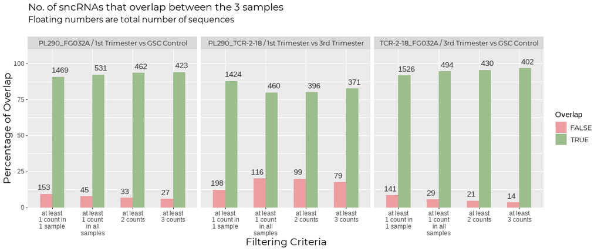

```r
ovp <- ovp %>%
  mutate(perc = (Freq/total)*100)

ovp %>%
  ggplot(aes(x = Filter, y = perc, fill = ovp)) +
  geom_bar(stat = "identity", position = position_dodge(), width = 0.6) +
  geom_text(aes(label = Freq), vjust = -0.8, colour = "#333333", position = position_dodge(0.80)) +
  #scale_y_discrete(expand = c(0,100)) +
  scale_fill_manual(values = col_compare, name = "Overlap") +
  coord_cartesian(y = c(0,110)) +
  scale_y_continuous(labels = comma, expand = c(0, 0)) +
  labs(title = "No. of sncRNAs that overlap between the 3 samples", subtitle = "Floating numbers are total number of sequences\n ", x = "Filtering Criteria", y = "Percentage of Overlap") +
  my_theme_2 +
  facet_grid(~which)
```

Now, if I were to exclude the GSC Control sample from the initial `eDat2` itself, the following sequences seleected won’t be an overrepresentation of the ‘healthy, normative control’.

### **2.6 Redoing 2.1 - 2.5 without FG032A**

```r
eDat2 <- eDat_fil [c(1:12)] #removing GSC control sample

eDat2 <- eDat2 %>% #removing sequences with less than 1 read count across all samples
  rownames_to_column(var = "miRNA") %>%
  mutate(Sum = rowSums(.[2:13])) %>%
  filter(Sum >= 1) %>%
  column_to_rownames(var = "miRNA") %>%
  dplyr::select(-Sum)

nrow(eDat2) #1865
```

```
## [1] 1865
```

```r
s1_fil1 <- eDat2 [c(1:6)]

s1_fil1 <- s1_fil1 %>% #removing sequences with less than 1 read count across all samples
  rownames_to_column(var = "miRNA") %>%
  mutate(Sum = rowSums(.[2:7])) %>%
  filter(Sum >= 1) %>%
  column_to_rownames(var = "miRNA") %>%
  dplyr::select(-Sum)

nrow(s1_fil1) #1162
```

```
## [1] 1622
```

```r
s1_fil2 <- s1_fil1 %>% #keeping sequences with counts of atleast 1 in all of the samples
  rownames_to_column(var = "miRNA") %>%
  filter_all(all_vars(. >= 1))  %>%
  column_to_rownames(var = "miRNA")

nrow(s1_fil2) #576
```

```
## [1] 576
```

```r
s1_fil3 <- s1_fil1 %>% #keeping sequences with counts of atleast 2 in all of the samples
  rownames_to_column(var = "miRNA") %>%
  filter_all(all_vars(. >= 2))  %>%
  column_to_rownames(var = "miRNA")

nrow(s1_fil3) #495
```

```
## [1] 495
```

```r
s1_fil4 <- s1_fil1 %>% #keeping sequences with counts of atleast 3 in all of the samples
  rownames_to_column(var = "miRNA") %>%
  filter_all(all_vars(. >= 3))  %>%
  column_to_rownames(var = "miRNA")

nrow(s1_fil4) #450
```

```
## [1] 450
```

```r
s2_fil1 <- eDat2 [c(7:12)]

s2_fil1 <- s2_fil1 %>% #removing sequences with less than 1 read count across all samples
  rownames_to_column(var = "miRNA") %>%
  mutate(Sum = rowSums(.[2:7])) %>%
  filter(Sum >= 1) %>%
  column_to_rownames(var = "miRNA") %>%
  dplyr::select(-Sum)

nrow(s2_fil1) #1667
```

```
## [1] 1667
```

```r
s2_fil2 <- s2_fil1 %>% #keeping sequences with counts of atleast 1 in all of the samples
  rownames_to_column(var = "miRNA") %>%
  filter_all(all_vars(. >= 1))  %>%
  column_to_rownames(var = "miRNA")

nrow(s2_fil2) #523
```

```
## [1] 523
```

```r
s2_fil3 <- s2_fil1 %>% #keeping sequences with counts of atleast 2 in all of the samples
  rownames_to_column(var = "miRNA") %>%
  filter_all(all_vars(. >= 2))  %>%
  column_to_rownames(var = "miRNA")

nrow(s2_fil3) #451
```

```
## [1] 451
```

```r
s2_fil4 <- s2_fil1 %>% #keeping sequences with counts of atleast 3 in all of the samples
  rownames_to_column(var = "miRNA") %>%
  filter_all(all_vars(. >= 3))  %>%
  column_to_rownames(var = "miRNA")

nrow(s2_fil4) #416
```

```
## [1] 416
```

After subsetting into T1 and T3, the filtering however removed none - which is good, meaning that the GSC sample isn’t overestimating the majority of the sequences.

## **3.0 Filtering by Titration Counts**

```r
eDat_fil <- eDat [-c(1,8,9,16,17,24)] #removing 0 and 500ng samples

eDat2 <- eDat_fil %>% #removing sequences with less than 1 read count across all samples
  rownames_to_column(var = "miRNA") %>%
  mutate(Sum = rowSums(.[2:19])) %>%
  filter(Sum >= 1) %>%
  column_to_rownames(var = "miRNA") %>%
  dplyr::select(-Sum)


list_250 <- eDat2 [c(1, 7, 13)]
list_100 <- eDat2 [c(2, 8, 14)]
list_50 <- eDat2 [c(3, 9, 15)]
list_25 <- eDat2 [c(4, 10, 16)]
list_5 <- eDat2 [c(5, 11, 17)]
list_1 <- eDat2 [c(6, 12, 18)]

titra_list <- list (list_250, list_100, list_50, list_25, list_5, list_1) #put all dfs in a list

#sample_names <- c("PL290", "TCR-5-18", "FG032A")
#titrations <- c("250ng", "100ng", "50ng", "25ng", "10ng", "5ng")

#titra_list <- lapply(titra_list, setNames, sample_names) #change colnames of all dfs
```

I’m going to tweak the 4 filtering criteria, given now that we have only 3 samples per group of tirations.

1. at least 1 count in 1 sample
2. At least 1 count in all samples
3. At least 2 counts in all samples
4. At least 3 counts in all samples

I’m then going to compare the total RPM to observe how much of a difference there is depending upon the filters for each of the samples.

```r
fil_250_1 <- titra_list[[1]] %>% #subset from the list that stores all the titrations
  rownames_to_column(var = "miRNA") %>%
  mutate(Sum = rowSums(.[2:4])) %>%  #removing sequences with less than 1 read count across all samples
  filter(Sum >= 1) %>%
  column_to_rownames(var = "miRNA") %>%
  dplyr::select(-Sum)  %>%
  mutate(filter = "at least\n1 count in\n1 sample")

nrow(fil_250_1) # 1585
```

```
## [1] 1585
```

```r
fil_250_2 <- titra_list[[1]] %>% #keeping sequences with counts of atleast 1 in all of the samples
  rownames_to_column(var = "miRNA") %>%
  filter_all(all_vars(. >= 1))  %>%
  column_to_rownames(var = "miRNA") %>%
  mutate(filter = "at least\n1 count\nin all\nsamples")

nrow(fil_250_2) #782
```

```
## [1] 782
```

```r
fil_250_3 <- titra_list[[1]] %>% #keeping sequences with counts of atleast 2 in all of the samples
  rownames_to_column(var = "miRNA") %>%
  filter_all(all_vars(. >= 2))  %>%
  column_to_rownames(var = "miRNA") %>%
  mutate(filter = "at least\n2 counts")

nrow(fil_250_3) #678
```

```
## [1] 678
```

```r
fil_250_4 <- titra_list[[1]] %>% #keeping sequences with counts of atleast 3 in all of the samples
  rownames_to_column(var = "miRNA") %>%
  filter_all(all_vars(. >= 3))  %>%
  column_to_rownames(var = "miRNA") %>%
  mutate(filter = "at least\n3 counts")

nrow(fil_250_4) #625
```

```
## [1] 625
```

```r
fil_250 <- list(fil_250_1, fil_250_2, fil_250_3, fil_250_4)


#fil_250_1 <- fil_250_1 %>%
#  rownames_to_column(var = "miRNA") %>%
#  adorn_totals("row") %>%
#  untabyl() %>%
#  `row.names<-`(., NULL) %>%
#  column_to_rownames(var = "miRNA") %>%
#  dplyr::arrange(desc(.[3]))


#MY FIRST FUCNTION! --> Copying what I do do for a single df to a separate function to apply to the list
f1 <- function (x) {x %>%
    rownames_to_column(var = "miRNA") %>%
    adorn_totals("row") %>%
    untabyl () %>%
    `row.names<-`(., NULL) %>%
    column_to_rownames(var = "miRNA") %>%
    dplyr::arrange(desc(.[3]))
}

fil_250 <- lapply(fil_250, f1)#lapply = apply for list, f = function describing the dplyr steps
fil_250 <- lapply(fil_250, function(x) mutate(x, titration = "250ng"))

#attributes(list_250) <- NULL #adorn_totals transformed df into different data type
#f2 <- function (x) {
#  attributes(x) <- NULL
#}



#1 count across all 3 samples
test <- titra_list[[1]] %>%
 rownames_to_column(var = "miRNA") %>%
  filter_all(all_vars(. >= 1))  %>%
  column_to_rownames(var = "miRNA") #467

#2 counts across all 3 samples
test2 <- titra_list[[1]] %>%
 rownames_to_column(var = "miRNA") %>%
  filter_all(all_vars(. >= 2))  %>%
  column_to_rownames(var = "miRNA") #429
```

I’m now going to make a plot depicting the total number of sequences based on the filtering criteria for all the tirations

```r
fil_seq <- factor(c("250ng", "100ng", "50ng", "25ng", "5ng", "1ng"), levels = c("250ng", "100ng", "50ng", "25ng", "5ng", "1ng"))

fil_seq <- as.data.frame(fil_seq)
colnames(fil_seq) [1] <- "Titrations"

fil_seq <- fil_seq %>%
  mutate(count = 4) %>% #multiply the rows 4 times
  uncount(count)

fil_seq$Filter <- factor(c("at least 1 count in 1 sample", "at least 1 count in all samples", "at least 2 counts", "at least 3 counts"), levels = c("at least 1 count in 1 sample", "at least 1 count in all samples", "at least 2 counts", "at least 3 counts"))

fil_totals <- as.data.frame(nrow(fil_250_1))
fil_totals$a <- nrow(fil_250_2)
fil_totals$b <- nrow(fil_250_3)
fil_totals$c <- nrow(fil_250_4)
fil_totals$d <- nrow(fil_100_1)
fil_totals$e <- nrow(fil_100_2)
fil_totals$f <- nrow(fil_100_3)
fil_totals$g <- nrow(fil_100_4)
fil_totals$h <- nrow(fil_50_1)
fil_totals$i <- nrow(fil_50_2)
fil_totals$j <- nrow(fil_50_3)
fil_totals$k <- nrow(fil_50_4)
fil_totals$l <- nrow(fil_25_1)
fil_totals$m <- nrow(fil_25_2)
fil_totals$n <- nrow(fil_25_3)
fil_totals$o <- nrow(fil_25_4)
fil_totals$p <- nrow(fil_5_1)
fil_totals$q <- nrow(fil_5_2)
fil_totals$r <- nrow(fil_5_3)
fil_totals$s <- nrow(fil_5_4)
fil_totals$t <- nrow(fil_1_1)
fil_totals$u <- nrow(fil_1_2)
fil_totals$v <- nrow(fil_1_3)
fil_totals$w <- nrow(fil_1_4)

fil_totals <- as.data.frame(t(fil_totals))

colnames(fil_totals) [1] <- "Total_Sequences"

fil_seq <- cbind(fil_seq, fil_totals)

#fil_seq$Total_Sequences <- as.numeric(c("18689", "4877", "1988", "1088", "13723", "3901", "1632", "929", "14667", "4717", "2006", "1122", "13468", "3900", "1683", "975", "15313", "4989" , "2268", "1346", "12575", "1706", "705", "396")) --> WRONG. NOT REPRODUCIBLE

str(fil_seq)
```

```
## 'data.frame':    24 obs. of  3 variables:
##  $ Titrations     : Factor w/ 6 levels "250ng","100ng",..: 1 1 1 1 2 2 2 2 3 3 ...
##  $ Filter         : Factor w/ 4 levels "at least 1 count in 1 sample",..: 1 2 3 4 1 2 3 4 1 2 ...
##  $ Total_Sequences: int  1585 782 678 625 1628 934 790 726 1666 965 ...
```

```r
head(fil_seq)
```

```
##                 Titrations                          Filter Total_Sequences
## nrow(fil_250_1)      250ng    at least 1 count in 1 sample            1585
## a                    250ng at least 1 count in all samples             782
## b                    250ng               at least 2 counts             678
## c                    250ng               at least 3 counts             625
## d                    100ng    at least 1 count in 1 sample            1628
## e                    100ng at least 1 count in all samples             934
```

```r
g1 <- fil_seq %>%
  ggplot(aes(x = Titrations, y = Total_Sequences, fill = Filter)) +
  geom_bar(stat = "identity", position = position_dodge(), width = 0.68) +
  geom_text(aes(label = Total_Sequences), vjust = -0.8, colour = "#333333", position = position_dodge(0.65)) +
  scale_fill_manual(values = col_filters) +
  labs(title = "Comparison of Total No of Sequences - Rob Lab + GSC Samples", subtitle = "by 4 Filtering Criteria") +
  scale_y_continuous(labels = comma, expand = c(0, 0)) + #to make yaxis units as whole numbers rather than in exponential form
  my_theme +
  coord_cartesian(y = c(0,2000)) +
  theme(legend.position = "bottom")

#g1
```

Now, I’m going to bind the first rows that contain the total RPM based on the different filtering steps together to make a single df that I can use to plot the difference between the RPMs for the differing titrations.

```r
#figure out how to extract Total RPM row

#test <- rbind(fil_250_1[1,], fil_100_1[1,])
#dfnew <- (fil_250[[c(1)]]) ---> Nope
#dfnew <- Map(head, fil_250[1], 1) #by purrr
#dfnew <- lapply(fil_250[1], head, 1) #by lapply
#dfnew <- lapply(fil_250[1], function(x) x[1,]) #first row of first df
#dfnew <- lapply(fil_250, function(x) x[1,]) #first rows of all dfs


dfnew <- lapply(fil_250, function(x) x[,1]) # --> WORKS!
#dfnew <- as.data.frame(dfnew)
```

```r
f2 <- function (x){
  lapply(x)
  function(y){y[1,]
  }
} #Nope

#dfnew <- as.data.frame(rbind(lapply(fil_250, function(x) x[1,]))) --> Nope
df_250 <- do.call(rbind, (lapply(fil_250, function(x) x[1,])))
df_250$filter <- factor(c("at least 1 count in 1 sample", "at least 1 count in all samples", "at least 2 counts", "at least 3 counts"), levels = c("at least 1 count in 1 sample", "at least 1 count in all samples", "at least 2 counts", "at least 3 counts"))

df_100 <- do.call(rbind, (lapply(fil_100, function(x) x[1,])))
df_100$filter <- factor(c("at least 1 count in 1 sample", "at least 1 count in all samples", "at least 2 counts", "at least 3 counts"), levels = c("at least 1 count in 1 sample", "at least 1 count in all samples", "at least 2 counts", "at least 3 counts"))

df_50 <- do.call(rbind, (lapply(fil_50, function(x) x[1,])))
df_50$filter <- factor(c("at least 1 count in 1 sample", "at least 1 count in all samples", "at least 2 counts", "at least 3 counts"), levels = c("at least 1 count in 1 sample", "at least 1 count in all samples", "at least 2 counts", "at least 3 counts"))

df_25 <- do.call(rbind, (lapply(fil_25, function(x) x[1,])))
df_25$filter <- factor(c("at least 1 count in 1 sample", "at least 1 count in all samples", "at least 2 counts", "at least 3 counts"), levels = c("at least 1 count in 1 sample", "at least 1 count in all samples", "at least 2 counts", "at least 3 counts"))

df_5 <- do.call(rbind, (lapply(fil_5, function(x) x[1,])))
df_5$filter <- factor(c("at least 1 count in 1 sample", "at least 1 count in all samples", "at least 2 counts", "at least 3 counts"), levels = c("at least 1 count in 1 sample", "at least 1 count in all samples", "at least 2 counts", "at least 3 counts"))

df_1 <- do.call(rbind, (lapply(fil_1, function(x) x[1,])))
df_1$filter <- factor(c("at least 1 count in 1 sample", "at least 1 count in all samples", "at least 2 counts", "at least 3 counts"), levels = c("at least 1 count in 1 sample", "at least 1 count in all samples", "at least 2 counts", "at least 3 counts"))

list_fil <- list (df_250, df_100, df_50, df_25, df_5, df_1)

list_names <- c("PL290", "TCR-5-18", "FG032A", "Filter", "Titration")

list_fil <- lapply(list_fil, setNames, list_names)

#list_fil <- lapply(listrbind(list_fil[1], list_fil[2], list_fil[3], list_fil[4], list_fil[5], list_fil[6]))

list_fil <- list_fil %>%
  bind_rows() %>% #rbind all rows within a list
  rowid_to_column(var = "ID") %>%
  column_to_rownames(var = "ID")  %>%
  mutate(Titration = fct_relevel(Titration, c("250ng", "100ng", "50ng", "25ng", "5ng", "1ng")))

list_fil <- list_fil %>%
  mutate_if(is.numeric, round)

list_fil %>%
  kable(caption = "Total RPM by Filetring Criteria") %>%
  kable_styling(bootstrap_options = c("striped", "hover", "condensed", full_width = F, position = "right", fixed_thead = T))
```

Total RPM by Filetring Criteria

| PL290 | TCR-5-18 | FG032A | Filter | Titration |
| --- | --- | --- | --- | --- |
| 1675858 | 2430780 | 3331933 | at least 1 count in 1 sample | 250ng |
| 1673689 | 2429207 | 2744627 | at least 1 count in all samples | 250ng |
| 1672339 | 2428020 | 2666546 | at least 2 counts | 250ng |
| 1671136 | 2427073 | 2618222 | at least 3 counts | 250ng |
| 1034504 | 2300216 | 3060355 | at least 1 count in 1 sample | 100ng |
| 1034177 | 2299391 | 3049468 | at least 1 count in all samples | 100ng |
| 1033881 | 2298886 | 3047235 | at least 2 counts | 100ng |
| 1033664 | 2298254 | 3045443 | at least 3 counts | 100ng |
| 1165558 | 2389038 | 3078477 | at least 1 count in 1 sample | 50ng |
| 1165219 | 2388359 | 3076425 | at least 1 count in all samples | 50ng |
| 1164844 | 2387726 | 3075375 | at least 2 counts | 50ng |
| 1164473 | 2387222 | 3074342 | at least 3 counts | 50ng |
| 1129421 | 1820656 | 2116901 | at least 1 count in 1 sample | 25ng |
| 1128984 | 1819906 | 2115873 | at least 1 count in all samples | 25ng |
| 1128603 | 1819501 | 2115196 | at least 2 counts | 25ng |
| 1128401 | 1819024 | 2114514 | at least 3 counts | 25ng |
| 768446 | 1049658 | 1924206 | at least 1 count in 1 sample | 5ng |
| 767538 | 1049218 | 1921134 | at least 1 count in all samples | 5ng |
| 767097 | 1048938 | 1918933 | at least 2 counts | 5ng |
| 766741 | 1048785 | 1918017 | at least 3 counts | 5ng |
| 131579 | 184513 | 918426 | at least 1 count in 1 sample | 1ng |
| 131028 | 184246 | 907293 | at least 1 count in all samples | 1ng |
| 130834 | 184038 | 899700 | at least 2 counts | 1ng |
| 130671 | 183920 | 896687 | at least 3 counts | 1ng |

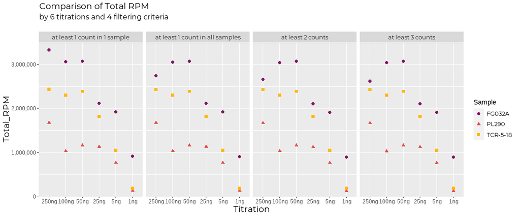

[figure not shown]

```r
#list_fil <- list_fil %>%
 #mutate_all(funs(str_replace(., "less than 1 count across all samples", "less than 1 count/nacross all samples"))) #reformat the Filter names

list_fil %>%
  pivot_longer(cols = 1:3, names_to = "Sample", values_to = "Total_RPM") %>%
  ggplot(aes(x = Titration, y = Total_RPM, color = Sample, shape = Sample)) +
  geom_point(size = 2) +
  scale_color_manual(values = col_samp) +
  my_theme_2 +
  labs(title = "Comparison of Total RPM", subtitle = "by 6 titrations and 4 filtering criteria\n") +
  coord_cartesian(y = c(0, 3500000)) +
  scale_y_continuous(labels = comma, expand = c(0, 0)) + #to make yaxis units as whole numbers rather than in exponential form
  facet_grid(~Filter)
```

## **4.0 Filtering by Percentage of Samples**

Let’s go with retaining / filtering for sequences present in at least:

1. 10% of samples (10% of 18 is 1.8 –> I’ll round off to the next whole number: 2)
2. 20% of samples (3.6 –> 4)
3. 30% of samples (5.4 –> 6)
4. 40% of samples (7.2 –> 8)
5. 50% of samples (9.0 –> 9)
6. 60% of samples (10.8 –> 11)
7. 70% of samples (12.6 –> 13)
8. 80% of samples (14.4 –> 15)

In this case, I’m converting the zero’s to NAs and then counting the total number of NAs. So, the above numbers in reverse when considering NAs/0 as the baseline:

1. 10% of samples (16 NAs)
2. 20% of samples (14 NAs)
3. 30% of samples (12 NAs)
4. 40% of samples (10 NAs)
5. 50% of samples (9 NAs)
6. 60% of samples (7 NAs)
7. 70% of samples (5 NAs)
8. 80% of samples (3 NAs)

```r
head(eDat_fil)
```

```
##                            m19817 m19818 m19819 m19820 m19821 m19822 m19825
## hsa-let-7a-1_hsa-let-7a-3p     37     11     12      7      4      0     50
## hsa-let-7a-1_hsa-let-7a-5p   6474   5507   6877   4629   3403    645  14779
## hsa-let-7a-2_hsa-let-7a-5p   6424   5491   6850   4609   3398    644  14657
## hsa-let-7a-3_hsa-let-7a-3p     38     11     12      7      5      0     50
## hsa-let-7a-3_hsa-let-7a-5p   6448   5507   6861   4621   3418    642  14524
## hsa-let-7b_hsa-let-7b-3p        6      1      0      5      0      0     13
##                            m19826 m19827 m19828 m19829 m19830 m19833 m19834
## hsa-let-7a-1_hsa-let-7a-3p     45     24     13      1      0      1    110
## hsa-let-7a-1_hsa-let-7a-5p  15888  17171  13488   9730   1021   4692  24736
## hsa-let-7a-2_hsa-let-7a-5p  15768  17021  13386   9733   1021   4645  24423
## hsa-let-7a-3_hsa-let-7a-3p     45     24     13      1      0      1    110
## hsa-let-7a-3_hsa-let-7a-5p  15661  16875  13306   9693   1025   4646  24259
## hsa-let-7b_hsa-let-7b-3p        6     13      4      0      0      1     34
##                            m19835 m19836 m19837 m19838
## hsa-let-7a-1_hsa-let-7a-3p    108     45     14      0
## hsa-let-7a-1_hsa-let-7a-5p  25710  18768  18069   7837
## hsa-let-7a-2_hsa-let-7a-5p  25407  18593  17985   7861
## hsa-let-7a-3_hsa-let-7a-3p    108     45     14      0
## hsa-let-7a-3_hsa-let-7a-5p  25301  18475  17932   7863
## hsa-let-7b_hsa-let-7b-3p       49     14     12      2
```

```r
eDat_fil <- eDat_fil %>%
  replace(.==0, NA)

t_eDat_fil <- as.data.frame(t(eDat_fil))

clsums <- colSums(is.na(t_eDat_fil))

t_eDat_fil <- rbind(t_eDat_fil, clsums)

eDat_fil <- as.data.frame(t(t_eDat_fil))

colnames(eDat_fil)[19] <- "Zero_Counts"

head(eDat_fil)
```

```
##                            m19817 m19818 m19819 m19820 m19821 m19822 m19825
## hsa-let-7a-1_hsa-let-7a-3p     37     11     12      7      4     NA     50
## hsa-let-7a-1_hsa-let-7a-5p   6474   5507   6877   4629   3403    645  14779
## hsa-let-7a-2_hsa-let-7a-5p   6424   5491   6850   4609   3398    644  14657
## hsa-let-7a-3_hsa-let-7a-3p     38     11     12      7      5     NA     50
## hsa-let-7a-3_hsa-let-7a-5p   6448   5507   6861   4621   3418    642  14524
## hsa-let-7b_hsa-let-7b-3p        6      1     NA      5     NA     NA     13
##                            m19826 m19827 m19828 m19829 m19830 m19833 m19834
## hsa-let-7a-1_hsa-let-7a-3p     45     24     13      1     NA      1    110
## hsa-let-7a-1_hsa-let-7a-5p  15888  17171  13488   9730   1021   4692  24736
## hsa-let-7a-2_hsa-let-7a-5p  15768  17021  13386   9733   1021   4645  24423
## hsa-let-7a-3_hsa-let-7a-3p     45     24     13      1     NA      1    110
## hsa-let-7a-3_hsa-let-7a-5p  15661  16875  13306   9693   1025   4646  24259
## hsa-let-7b_hsa-let-7b-3p        6     13      4     NA     NA      1     34
##                            m19835 m19836 m19837 m19838 Zero_Counts
## hsa-let-7a-1_hsa-let-7a-3p    108     45     14     NA           3
## hsa-let-7a-1_hsa-let-7a-5p  25710  18768  18069   7837           0
## hsa-let-7a-2_hsa-let-7a-5p  25407  18593  17985   7861           0
## hsa-let-7a-3_hsa-let-7a-3p    108     45     14     NA           3
## hsa-let-7a-3_hsa-let-7a-5p  25301  18475  17932   7863           0
## hsa-let-7b_hsa-let-7b-3p       49     14     12      2           5
```

Now I’ll filter according the number of NA’s present. First removing sequences that have 0 counts in all samples i.e. 18 zeros/NAs.

```r
eFil <- eDat_fil %>%
  filter(!Zero_Counts == 18)

nrow(eFil) #1911
```

**Sanity Check - The number of sequences we get when filtered to remove all sequences with zero to obtain eDat2 is the same as the number of sequences returned for eFil –> 1911 (differenct code, same result - GOOD)**

I’m now going to also check how many samples have counts of 2 or more in them, or more than counts of 3 in them.

```r
eDat_counts <- eDat2

eDat_counts <- eDat_counts %>% #freq of sequences having counts of 2 or more in each sample for seach seq
  rowwise() %>%
  do((.) %>%
  as.data.frame %>%
  mutate(more_than_2 = sum(. >= 2)))

eDat_min_2 <- eDat_counts %>% #df with seqs having atleast 2 counts in at least 1 samples
  filter(more_than_2 >= 2)
nrow(eDat_min_2) #1392

eDat_counts <- eDat_counts %>% #freq of sequences having counts of 3 or more in each sample for seach seq
  rowwise() %>%
  do((.) %>%
  as.data.frame %>%
  mutate(more_than_3 = sum(.[1:18] >= 3)))

eDat_min_3 <- eDat_counts %>%
  filter(more_than_2 >= 3) %>%  #df with seqs having atleast 2 counts in at least 1 samples
  dplyr::select(-more_than_2)
nrow(eDat_min_3) #1293
```

```r
perc_10 <- eDat_fil %>%
  filter(!Zero_Counts >= 16)

nrow(perc_10) #1629
```

```r
perc_20 <- eDat_fil %>%
  filter(!Zero_Counts >= 14)

nrow(perc_20) #1413
```

```r
perc_30 <- eDat_fil %>%
  filter(!Zero_Counts >= 12)

nrow(perc_30) #1257
```

```r
perc_40 <- eDat_fil %>%
  filter(!Zero_Counts >= 10)

nrow(perc_40) #1101
```

```r
perc_50 <- eDat_fil %>%
  filter(!Zero_Counts >= 9)

nrow(perc_50) #1027
```

```r
perc_60 <- eDat_fil %>%
  filter(!Zero_Counts >= 7)

nrow(perc_60) #904
```

```r
perc_70 <- eDat_fil %>%
  filter(!Zero_Counts >= 5)

nrow(perc_70) #782
```

```r
perc_80 <- eDat_fil %>%
  filter(!Zero_Counts >= 3)

nrow(perc_80) #664
```

Plottting the results:

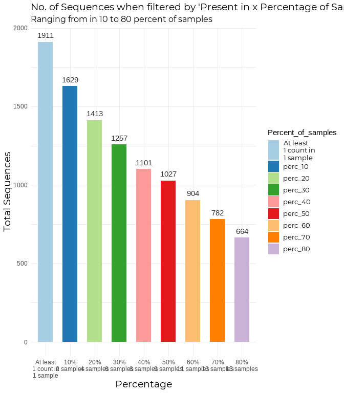

```r
fil_perc <- as.data.frame(nrow(eFil))

fil_perc$perc_10 <- nrow(perc_10)
fil_perc$perc_20 <- nrow(perc_20)
fil_perc$perc_30 <- nrow(perc_30)
fil_perc$perc_40 <- nrow(perc_40)
fil_perc$perc_50 <- nrow(perc_50)
fil_perc$perc_60 <- nrow(perc_60)
fil_perc$perc_70 <- nrow(perc_70)
fil_perc$perc_80 <- nrow(perc_80)

colnames(fil_perc)[1] <- "At least\n1 count in\n1 sample"

fil_perc <- as.data.frame(t(fil_perc))

colnames(fil_perc)[1] <- "Total_Sequences"

fil_perc <- fil_perc %>%
  rownames_to_column(var = "Percent_of_samples")

green_palette <- brewer.pal(name="Greens", n = 10)[2:10]

per_names <- c("At least\n1 count in\n1 sample", "10% \n2 samples", "20% \n4 samples", "30% \n6 samples", "40% \n8 samples", "50% \n9 samples", "60% \n11 samples", "70% \n13 samples", "80% \n15 samples")

fil_perc %>%
  ggplot(aes(x = Percent_of_samples, y = Total_Sequences, fill = Percent_of_samples)) +
  geom_bar(stat = "identity", width = 0.6) +
  geom_text(aes(label = Total_Sequences), vjust = -0.8, colour = "#333333") +
 # scale_fill_manual(values = green_palette) +
  scale_fill_brewer(palette = "Paired") +
  scale_x_discrete(labels = per_names) +
  labs(title = "No. of Sequences when filtered by 'Present in x Percentage of Samples' ", subtitle = "Ranging from in 10 to 80 percent of samples", x = "Percentage", y = "Total Sequences") +
  my_theme
```

Now, for the samples, we have a total of 6 samples, which means that the number of samples per percentage group will differ.

I can’t divide 6 samples up into 10 percentage groups, so I’ll divide it accordingly into 3:

1. 33.3% of samples
2. 66.6% of samples
3. 99.9% of samples

I can also just see how many sequences are present in 1, 2, 3, 4, 5, or all of the samples. Corresponding to the percentage of samples:

1. 1 sample = Present in 16.6% of the samples (100:6; ?:1)
2. 2 samples = 33.3%
3. 3 samples = 50%
4. 4 samples = 66.6%
5. 5 samples = 83.3%
6. 6 samples = 100%

### **4.1 Filtering for PL290 (by %)**

```r
head (s1_fil1)

s1_fil <- s1_fil1 %>%
  replace(.==0, NA)
t_s1_fil <- as.data.frame(t(s1_fil))
clsums <- colSums(is.na(t_s1_fil))
t_s1_fil <- rbind(t_s1_fil, clsums)
s1_fil <- as.data.frame(t(t_s1_fil))
colnames(s1_fil)[7] <- "Zero_Counts"
nrow(s1_fil) #1662

s1_fil <- s1_fil %>%
  filter(!Zero_Counts == 6) #SANITY CHECK PASSED

s1_perc_1 <- s1_fil %>%
  filter(Zero_Counts == 6)
nrow(s1_perc_1) #0 -->makes sense since we already removed sequences having 0 counts across all samples


s1_perc_2 <- s1_fil %>%
  filter(Zero_Counts == 5)
nrow(s1_perc_2) #358


s1_perc_3 <- s1_fil %>%
  filter(Zero_Counts == 4)
nrow(s1_perc_3) #199


s1_perc_4 <- s1_fil %>%
  filter(Zero_Counts == 3)
nrow(s1_perc_4) #139


s1_perc_5 <- s1_fil %>%
  filter(Zero_Counts == 2)
nrow(s1_perc_5) #152

s1_perc_6 <- s1_fil %>%
  filter(Zero_Counts == 1)
nrow(s1_perc_6) #198

s1_perc_all <- s1_fil %>%
  filter(Zero_Counts == 0)
nrow(s1_perc_all) #576


s1_fil_perc <- as.data.frame(nrow(s1_fil))

s1_fil_perc$perc_2 <- nrow(s1_perc_2)
s1_fil_perc$perc_3 <- nrow(s1_perc_3)
s1_fil_perc$perc_4 <- nrow(s1_perc_4)
s1_fil_perc$perc_5 <- nrow(s1_perc_5)
s1_fil_perc$perc_6 <- nrow(s1_perc_6)
s1_fil_perc$perc_all <- nrow(s1_perc_all)

colnames(s1_fil_perc)[1] <- "At least\n1 count in\n1 sample"

s1_fil_perc <- as.data.frame(t(s1_fil_perc))

colnames(s1_fil_perc)[1] <- "Total_Sequences"

s1_fil_perc <- s1_fil_perc %>%
  rownames_to_column(var = "Percent_of_samples")

s1_fil_perc$Sample <- "Rob Lab T1"


#In more than x% of samples

s1_perc_2 <- s1_fil %>%
  filter(Zero_Counts >= 5)
nrow(s1_perc_2) #358

s1_perc_3 <- s1_fil %>%
  filter(Zero_Counts >= 4)
nrow(s1_perc_3) #557

s1_perc_4 <- s1_fil %>%
  filter(Zero_Counts >= 3)
nrow(s1_perc_4) #696

s1_perc_5 <- s1_fil %>%
  filter(Zero_Counts >= 2)
nrow(s1_perc_5) #848

s1_perc_6 <- s1_fil %>%
  filter(Zero_Counts >= 1)
nrow(s1_perc_6) #1046

s1_perc_all <- s1_fil %>%
  filter(Zero_Counts == 0)
nrow(s1_perc_all) #576

s1_fil_add <- as.data.frame(nrow(s1_perc_all))

s1_fil_add$perc_2 <- nrow(s1_perc_2)
s1_fil_add$perc_3 <- nrow(s1_perc_3)
s1_fil_add$perc_4 <- nrow(s1_perc_4)
s1_fil_add$perc_5 <- nrow(s1_perc_5)
s1_fil_add$perc_6 <- nrow(s1_perc_6)
s1_fil_add$atleast <- nrow(s1_fil)

s1_fil_add <- as.data.frame(t(s1_fil_add))

s1_fil_add <- s1_fil_add %>%
  rownames_to_column(var = "Percent_of_samples")

colnames(s1_fil_add)[2] <- "Total_Sequences"

s1_fil_add$Sample <- "Rob Lab T1"
```

[output not shown]

### **4.2 Filtering for TCR-5-18 (by %)**

```r
head (s2_fil1)

s2_fil <- s2_fil1 %>%
  replace(.==0, NA)
t_s2_fil <- as.data.frame(t(s2_fil))
clsums <- colSums(is.na(t_s2_fil))
t_s2_fil <- rbind(t_s2_fil, clsums)
s2_fil <- as.data.frame(t(t_s2_fil))
colnames(s2_fil)[7] <- "Zero_Counts"
nrow(s2_fil) #1667

s2_fil <- s2_fil %>%
  filter(!Zero_Counts == 6) #SANITY CHECK PASSED

s2_perc_2 <- s2_fil %>%
  filter(Zero_Counts == 5)
nrow(s2_perc_2)


s2_perc_3 <- s2_fil %>%
  filter(Zero_Counts == 4)
nrow(s2_perc_3)


s2_perc_4 <- s2_fil %>%
  filter(Zero_Counts == 3)
nrow(s2_perc_4)


s2_perc_5 <- s2_fil %>%
  filter(Zero_Counts == 2)
nrow(s2_perc_5)

s2_perc_6 <- s2_fil %>%
  filter(Zero_Counts == 1)
nrow(s2_perc_6)

s2_perc_all <- s2_fil %>%
  filter(Zero_Counts == 0)
nrow(s2_perc_all)


s2_fil_perc <- as.data.frame(nrow(s2_fil))

s2_fil_perc$perc_2 <- nrow(s2_perc_2)
s2_fil_perc$perc_3 <- nrow(s2_perc_3)
s2_fil_perc$perc_4 <- nrow(s2_perc_4)
s2_fil_perc$perc_5 <- nrow(s2_perc_5)
s2_fil_perc$perc_6 <- nrow(s2_perc_6)
s2_fil_perc$perc_all <- nrow(s2_perc_all)

colnames(s2_fil_perc)[1] <- "At least\n1 count in\n1 sample"

s2_fil_perc <- as.data.frame(t(s2_fil_perc))

colnames(s2_fil_perc)[1] <- "Total_Sequences"

s2_fil_perc <- s2_fil_perc %>%
  rownames_to_column(var = "Percent_of_samples")

s2_fil_perc$Sample <- "Rob Lab Term"



#In more than x% of samples

s2_perc_2 <- s2_fil %>%
  filter(Zero_Counts >= 5)
nrow(s2_perc_2)

s2_perc_3 <- s2_fil %>%
  filter(Zero_Counts >= 4)
nrow(s2_perc_3)

s2_perc_4 <- s2_fil %>%
  filter(Zero_Counts >= 3)
nrow(s2_perc_4)

s2_perc_5 <- s2_fil %>%
  filter(Zero_Counts >= 2)
nrow(s2_perc_5)

s2_perc_6 <- s2_fil %>%
  filter(Zero_Counts >= 1)
nrow(s2_perc_6)

s2_perc_all <- s2_fil %>%
  filter(Zero_Counts == 0)
nrow(s2_perc_all)

s2_fil_add <- as.data.frame(nrow(s2_perc_all))

s2_fil_add$perc_2 <- nrow(s2_perc_2)
s2_fil_add$perc_3 <- nrow(s2_perc_3)
s2_fil_add$perc_4 <- nrow(s2_perc_4)
s2_fil_add$perc_5 <- nrow(s2_perc_5)
s2_fil_add$perc_6 <- nrow(s2_perc_6)
s2_fil_add$atleast <- nrow(s2_fil)

s2_fil_add <- as.data.frame(t(s2_fil_add))

s2_fil_add <- s2_fil_add %>%
  rownames_to_column(var = "Percent_of_samples")

colnames(s2_fil_add)[2] <- "Total_Sequences"

s2_fil_add$Sample <- "Rob Lab Term"
```

[output not shown]

### **4.2 Filtering for FG032A (by %)**

```r
head (con_fil1)

con_fil <- con_fil1 %>%
  replace(.==0, NA)
t_con_fil <- as.data.frame(t(con_fil))
clsums <- colSums(is.na(t_con_fil))
t_con_fil <- rbind(t_con_fil, clsums)
con_fil <- as.data.frame(t(t_con_fil))
colnames(con_fil)[7] <- "Zero_Counts"
nrow(con_fil) #1682

con_fil <- con_fil %>%
  filter(!Zero_Counts == 6) #SANITY CHECK PASSED

#in X% of samples

con_perc_2 <- con_fil %>%
  filter(Zero_Counts == 5)
nrow(con_perc_2)


con_perc_3 <- con_fil %>%
  filter(Zero_Counts == 4)
nrow(con_perc_3)


con_perc_4 <- con_fil %>%
  filter(Zero_Counts == 3)
nrow(con_perc_4)


con_perc_5 <- con_fil %>%
  filter(Zero_Counts == 2)
nrow(con_perc_5)

con_perc_6 <- con_fil %>%
  filter(Zero_Counts == 1)
nrow(con_perc_6)

con_perc_all <- con_fil %>%
  filter(Zero_Counts == 0)
nrow(con_perc_all)


con_fil_perc <- as.data.frame(nrow(con_fil))

con_fil_perc$perc_2 <- nrow(con_perc_2)
con_fil_perc$perc_3 <- nrow(con_perc_3)
con_fil_perc$perc_4 <- nrow(con_perc_4)
con_fil_perc$perc_5 <- nrow(con_perc_5)
con_fil_perc$perc_6 <- nrow(con_perc_6)
con_fil_perc$perc_all <- nrow(con_perc_all)


colnames(con_fil_perc)[1] <- "At least\n1 count in\n1 sample"

con_fil_perc <- as.data.frame(t(con_fil_perc))

colnames(con_fil_perc)[1] <- "Total_Sequences"

con_fil_perc <- con_fil_perc %>%
  rownames_to_column(var = "Percent_of_samples")

con_fil_perc$Sample <- "GSC Control"


#In more than x% of samples

con_perc_2 <- con_fil %>%
  filter(Zero_Counts >= 5)
nrow(con_perc_2)

con_perc_3 <- con_fil %>%
  filter(Zero_Counts >= 4)
nrow(con_perc_3)

con_perc_4 <- con_fil %>%
  filter(Zero_Counts >= 3)
nrow(con_perc_4)

con_perc_5 <- con_fil %>%
  filter(Zero_Counts >= 2)
nrow(con_perc_5)

con_perc_6 <- con_fil %>%
  filter(Zero_Counts >= 1)
nrow(con_perc_6)

con_perc_all <- con_fil %>%
  filter(Zero_Counts == 0)
nrow(con_perc_all)

con_fil_add <- as.data.frame(nrow(con_perc_all))

con_fil_add$perc_2 <- nrow(con_perc_2)
con_fil_add$perc_3 <- nrow(con_perc_3)
con_fil_add$perc_4 <- nrow(con_perc_4)
con_fil_add$perc_5 <- nrow(con_perc_5)
con_fil_add$perc_6 <- nrow(con_perc_6)
con_fil_add$atleast <- nrow(con_fil)

con_fil_add <- as.data.frame(t(con_fil_add))

con_fil_add <- con_fil_add %>%
  rownames_to_column(var = "Percent_of_samples")

colnames(con_fil_add)[2] <- "Total_Sequences"

con_fil_add$Sample <- "GSC Control"
```

[output not shown]

I’ll now do the same for the `eDat_min_2` and `eDat_min_3`, using sequences having counts of atleast 2 and above in x% of samples.

```
## # A tibble: 6 x 19
## # Rowwise:
##   m19817 m19818 m19819 m19820 m19821 m19822 m19825 m19826 m19827 m19828 m19829
##    <dbl>  <dbl>  <dbl>  <dbl>  <dbl>  <dbl>  <dbl>  <dbl>  <dbl>  <dbl>  <dbl>
## 1     37     11     12      7      4      0     50     45     24     13      1
## 2   6474   5507   6877   4629   3403    645  14779  15888  17171  13488   9730
## 3   6424   5491   6850   4609   3398    644  14657  15768  17021  13386   9733
## 4     38     11     12      7      5      0     50     45     24     13      1
## 5   6448   5507   6861   4621   3418    642  14524  15661  16875  13306   9693
## 6      6      1      0      5      0      0     13      6     13      4      0
## # ... with 8 more variables: m19830 <dbl>, m19833 <dbl>, m19834 <dbl>,
## #   m19835 <dbl>, m19836 <dbl>, m19837 <dbl>, m19838 <dbl>, more_than_2 <int>
```

```
## [1] 165
```

```
## [1] 94
```

```
## [1] 74
```

```
## [1] 115
```

```
## [1] 195
```

```
## [1] 495
```

```
## [1] 495
```

```
## [1] 690
```

```
## [1] 805
```

```
## [1] 879
```

```
## [1] 973
```

```
## [1] 1138
```

```
## [1] 117
```

```
## [1] 68
```

```
## [1] 63
```

```
## [1] 97
```

```
## [1] 190
```

```
## [1] 450
```

[output not shown]

```
## [1] 640
```

```
## [1] 737
```

```
## [1] 800
```

```
## [1] 868
```

```
## [1] 985
```

```
## # A tibble: 6 x 19
## # Rowwise:
##   m19817 m19818 m19819 m19820 m19821 m19822 m19825 m19826 m19827 m19828 m19829
##    <dbl>  <dbl>  <dbl>  <dbl>  <dbl>  <dbl>  <dbl>  <dbl>  <dbl>  <dbl>  <dbl>
## 1     37     11     12      7      4      0     50     45     24     13      1
## 2   6474   5507   6877   4629   3403    645  14779  15888  17171  13488   9730
## 3   6424   5491   6850   4609   3398    644  14657  15768  17021  13386   9733
## 4     38     11     12      7      5      0     50     45     24     13      1
## 5   6448   5507   6861   4621   3418    642  14524  15661  16875  13306   9693
## 6      6      1      0      5      0      0     13      6     13      4      0
## # ... with 8 more variables: m19830 <dbl>, m19833 <dbl>, m19834 <dbl>,
## #   m19835 <dbl>, m19836 <dbl>, m19837 <dbl>, m19838 <dbl>, more_than_2 <int>
```

```
## [1] 159
```

```
## [1] 110
```

```
## [1] 100
```

```
## [1] 174
```

```
## [1] 224
```

```
## [1] 451
```

```
## [1] 675
```

```
## [1] 849
```

```
## [1] 949
```

```
## [1] 1059
```

```
## [1] 1218
```

```
## [1] 138
```

```
## [1] 77
```

```
## [1] 81
```

```
## [1] 161
```

```
## [1] 204
```

```
## [1] 416
```

```
## [1] 620
```

```
## [1] 781
```

```
## [1] 862
```

```
## [1] 939
```

```
## [1] 1077
```

```
## # A tibble: 6 x 19
## # Rowwise:
##   m19817 m19818 m19819 m19820 m19821 m19822 m19825 m19826 m19827 m19828 m19829
##    <dbl>  <dbl>  <dbl>  <dbl>  <dbl>  <dbl>  <dbl>  <dbl>  <dbl>  <dbl>  <dbl>
## 1     37     11     12      7      4      0     50     45     24     13      1
## 2   6474   5507   6877   4629   3403    645  14779  15888  17171  13488   9730
## 3   6424   5491   6850   4609   3398    644  14657  15768  17021  13386   9733
## 4     38     11     12      7      5      0     50     45     24     13      1
## 5   6448   5507   6861   4621   3418    642  14524  15661  16875  13306   9693
## 6      6      1      0      5      0      0     13      6     13      4      0
## # ... with 8 more variables: m19830 <dbl>, m19833 <dbl>, m19834 <dbl>,
## #   m19835 <dbl>, m19836 <dbl>, m19837 <dbl>, m19838 <dbl>, more_than_2 <int>
```

```
## [1] 112
```

```
## [1] 102
```

```
## [1] 120
```

```
## [1] 143
```

```
## [1] 152
```

```
## [1] 723
```

```
## [1] 875
```

```
## [1] 1018
```

```
## [1] 1138
```

```
## [1] 1240
```

```
## [1] 1352
```

```
## [1] 69
```

```
## [1] 99
```

```
## [1] 98
```

```
## [1] 129
```

```
## [1] 153
```

```
## [1] 662
```

```
## [1] 815
```

```
## [1] 944
```

```
## [1] 1042
```

```
## [1] 1141
```

```
## [1] 1210
```

### **4.3 Plotting absolute sequences by %**

For sequences with minimum count of 1:

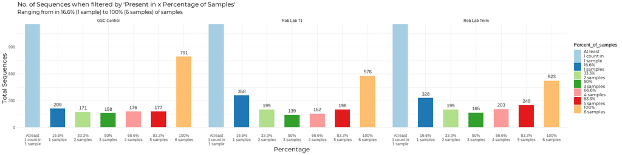

```r
per_names_2 <- c("At least\n1 count in\n1 sample", "16.6% \n1 samples", "33.3% \n2 samples", "50% \n3 samples", "66.6% \n4 samples", "83.3% \n5 samples", "100% \n6 samples")

perc <- rbind(s1_fil_perc, s2_fil_perc, con_fil_perc)

perc %>%
  ggplot(aes(x = Percent_of_samples, y = Total_Sequences, fill = Percent_of_samples)) +
  geom_bar(stat = "identity", width = 0.6) +
  geom_text(aes(label = Total_Sequences), vjust = -0.8, colour = "#333333") +
  scale_fill_brewer(palette = "Paired", labels = per_names_2) +
  scale_x_discrete(labels = per_names_2) +
  coord_cartesian (y =c(0, 1100)) +
  labs(title = "No. of Sequences when filtered by 'Present in x Percentage of Samples' ", subtitle = "Ranging from in 16.6% (1 sample) to 100% (6 samples) of samples", x = "Percentage", y = "Total Sequences") +
  my_theme +
  facet_grid(~Sample)
```

```r
per_names_3 <- factor(c("100% \n6 samples", ">= 83.3% \n>= 5 samples", ">= 66.6% \n>= 4 samples", ">= 50% \n>= 3 samples",">= 33.3% \n>= 2 samples", ">= 16.6% \n>= 1 sample", "At least\n1 count in\n1 sample"), levels = c("100% \n6 samples", ">= 83.3% \n>= 5 samples", ">= 66.6% \n>= 4 samples", ">= 50% \n>= 3 samples",">= 33.3% \n>= 2 samples",  ">= 16.6% \n>= 1 sample", "At least\n1 count in\n1 sample"))

perc_add <- rbind(s1_fil_add, s2_fil_add, con_fil_add)

perc_add$Percent_of_samples <- per_names_3

str(perc_add)
```

```
## 'data.frame':    21 obs. of  3 variables:
##  $ Percent_of_samples: Factor w/ 7 levels "100% \n6 samples",..: 1 2 3 4 5 6 7 1 2 3 ...
##  $ Total_Sequences   : int  576 358 557 696 848 1046 1622 523 328 527 ...
##  $ Sample            : chr  "Rob Lab T1" "Rob Lab T1" "Rob Lab T1" "Rob Lab T1" ...
```

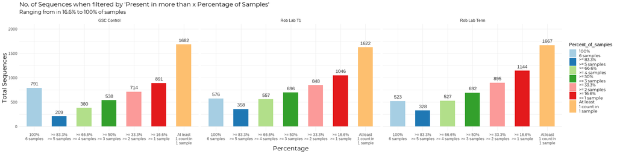

```r
perc_add %>%
  ggplot(aes(x = Percent_of_samples, y = Total_Sequences, fill = Percent_of_samples)) +
  geom_bar(stat = "identity", width = 0.6) +
  geom_text(aes(label = Total_Sequences), vjust = -0.8, colour = "#333333") +
  scale_fill_brewer(palette = "Paired", labels = per_names_3) +
  scale_x_discrete(labels = per_names_3) +
  coord_cartesian (y =c(0, 2000)) +
  labs(title = "No. of Sequences when filtered by 'Present in more than x Percentage of Samples' ", subtitle = "Ranging from in 16.6% to 100% of samples", x = "Percentage", y = "Total Sequences") +
  my_theme +
  facet_grid(~Sample)
```

For sequences with minimum count of 2:

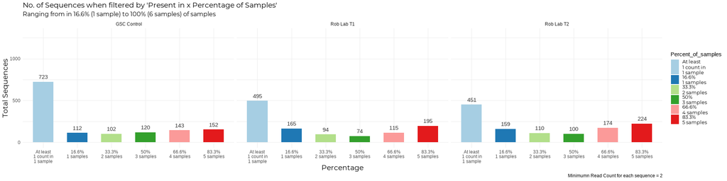

```r
all_min2_perc <- rbind(s1_min2_perc, s2_min2_perc, con_min2_perc)

per_names_2 <- factor(c("At least\n1 count in\n1 sample", "16.6% \n1 samples", "33.3% \n2 samples", "50% \n3 samples", "66.6% \n4 samples", "83.3% \n5 samples", "100% \n6 samples"), levels = c("At least\n1 count in\n1 sample", "16.6% \n1 samples", "33.3% \n2 samples", "50% \n3 samples", "66.6% \n4 samples", "83.3% \n5 samples", "100% \n6 samples"))

all_min2_perc %>%
  ggplot(aes(x = Percent_of_samples, y = Total_Sequences, fill = Percent_of_samples)) +
  geom_bar(stat = "identity", width = 0.6) +
  geom_text(aes(label = Total_Sequences), vjust = -0.8, colour = "#333333") +
  scale_fill_brewer(palette = "Paired", labels = per_names_2) +
  scale_x_discrete(labels = per_names_2) +
  coord_cartesian (y =c(0, 1300)) +
  labs(title = "No. of Sequences when filtered by 'Present in x Percentage of Samples' ", subtitle = "Ranging from in 16.6% (1 sample) to 100% (6 samples) of samples", x = "Percentage", y = "Total Sequences", caption = "Minimumn Read Count for each sequence = 2") +
  my_theme +
  facet_grid(~Sample)
```

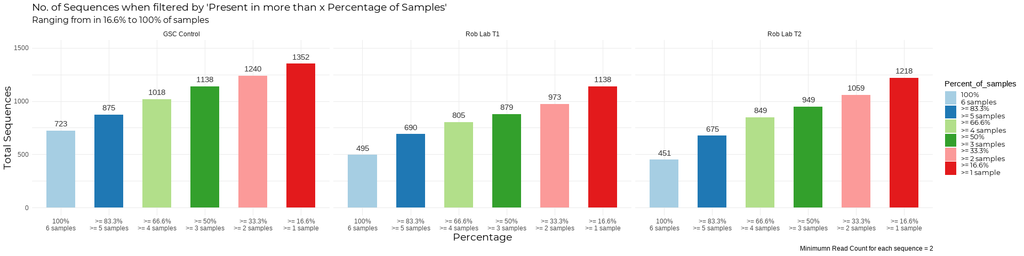

```r
all_min2_all <- rbind(s1_min2_all, s2_min2_all, con_min2_all)

per_names_3 <- factor(c("100% \n6 samples", ">= 83.3% \n>= 5 samples", ">= 66.6% \n>= 4 samples", ">= 50% \n>= 3 samples",">= 33.3% \n>= 2 samples", ">= 16.6% \n>= 1 sample"), levels = c("100% \n6 samples", ">= 83.3% \n>= 5 samples", ">= 66.6% \n>= 4 samples", ">= 50% \n>= 3 samples",">= 33.3% \n>= 2 samples",  ">= 16.6% \n>= 1 sample"))

all_min2_all$Percent_of_samples <- per_names_3

all_min2_all %>%
  ggplot(aes(x = Percent_of_samples, y = Total_Sequences, fill = Percent_of_samples)) +
  geom_bar(stat = "identity", width = 0.6) +
  geom_text(aes(label = Total_Sequences), vjust = -0.8, colour = "#333333") +
  scale_fill_brewer(palette = "Paired", labels = per_names_3) +
  scale_x_discrete(labels = per_names_3) +
  coord_cartesian (y =c(0, 1500)) +
  labs(title = "No. of Sequences when filtered by 'Present in more than x Percentage of Samples' ", subtitle = "Ranging from in 16.6% to 100% of samples", x = "Percentage", y = "Total Sequences", caption = "Minimumn Read Count for each sequence = 2") +
  my_theme +
  facet_grid(~Sample)
```

For sequences with minimum count of 3:

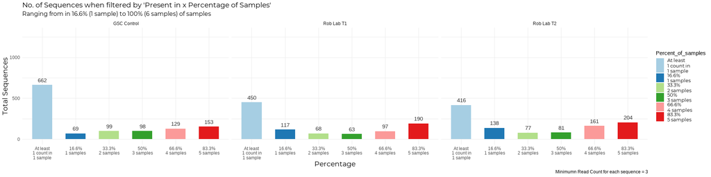

```r
all_min3_perc <- rbind(s1_min3_perc, s2_min3_perc, con_min3_perc)

per_names_2 <- factor(c("At least\n1 count in\n1 sample", "16.6% \n1 samples", "33.3% \n2 samples", "50% \n3 samples", "66.6% \n4 samples", "83.3% \n5 samples", "100% \n6 samples"), levels = c("At least\n1 count in\n1 sample", "16.6% \n1 samples", "33.3% \n2 samples", "50% \n3 samples", "66.6% \n4 samples", "83.3% \n5 samples", "100% \n6 samples"))

all_min3_perc %>%
  ggplot(aes(x = Percent_of_samples, y = Total_Sequences, fill = Percent_of_samples)) +
  geom_bar(stat = "identity", width = 0.6) +
  geom_text(aes(label = Total_Sequences), vjust = -0.8, colour = "#333333") +
  scale_fill_brewer(palette = "Paired", labels = per_names_2) +
  scale_x_discrete(labels = per_names_2) +
  coord_cartesian (y =c(0, 1300)) +
  labs(title = "No. of Sequences when filtered by 'Present in x Percentage of Samples' ", subtitle = "Ranging from in 16.6% (1 sample) to 100% (6 samples) of samples", x = "Percentage", y = "Total Sequences", caption = "Minimumn Read Count for each sequence = 3") +
  my_theme +
  facet_grid(~Sample)
```

[figure not shown]

```r
all_min3_all <- rbind(s1_min3_all, s2_min3_all, con_min3_all)

per_names_3 <- factor(c("100% \n6 samples", ">= 83.3% \n>= 5 samples", ">= 66.6% \n>= 4 samples", ">= 50% \n>= 3 samples",">= 33.3% \n>= 2 samples", ">= 16.6% \n>= 1 sample"), levels = c("100% \n6 samples", ">= 83.3% \n>= 5 samples", ">= 66.6% \n>= 4 samples", ">= 50% \n>= 3 samples",">= 33.3% \n>= 2 samples",  ">= 16.6% \n>= 1 sample"))

all_min3_all$Percent_of_samples <- per_names_3

all_min3_all %>%
  ggplot(aes(x = Percent_of_samples, y = Total_Sequences, fill = Percent_of_samples)) +
  geom_bar(stat = "identity", width = 0.6) +
  geom_text(aes(label = Total_Sequences), vjust = -0.8, colour = "#333333") +
  scale_fill_brewer(palette = "Paired", labels = per_names_3) +
  scale_x_discrete(labels = per_names_3) +
  coord_cartesian (y =c(0, 1300)) +
  labs(title = "No. of Sequences when filtered by 'Present in more than x Percentage of Samples' ", subtitle = "Ranging from in 16.6% to 100% of samples", x = "Percentage", y = "Total Sequences", caption = "Minimumn Read Count for each sequence = 3") +
  my_theme +
  facet_grid(~Sample)
```